# Identifying Environmentally Responsible US Public Transit Systems

Author

Dev Lala

Published

March 27, 2025

# Introduction

This analysis evaluates public transit agencies to determine the most eco-friendly ones. By integrating data from multiple sources, it uncovers key insights on environmental impact. The results will be presented in a press release announcing the GTA IV award winners.

# Objective

- **Data Integration**: Merge datasets from the National Transit Database and the Energy Information Administration for a comprehensive analysis.
- **Statistical Analysis**: Compute summary statistics to assess the environmental efficiency of public transit agencies.
- **Insightful Presentation**: Create a press release highlighting the greenest transit agencies, supported by key statistics and findings.

# **1. Data Acquisition**

```r
library(httr2)
library(rvest)
library(datasets)
library(purrr)
library(DT)
library(scales)
library(stringr)
library(dplyr)
```

```r
ensure_package <- function(pkg){
    pkg <- as.character(substitute(pkg))
    options(repos = c(CRAN = "https://cloud.r-project.org"))
    if(!require(pkg, character.only=TRUE)) install.packages(pkg)
    stopifnot(require(pkg, character.only=TRUE))
}

ensure_package(httr2)
ensure_package(rvest)
ensure_package(datasets)
ensure_package(purrr)
ensure_package(DT)

get_eia_sep <- function(state, abbr){
    state_formatted <- str_to_lower(state) |> str_replace_all("\\s", "")

    dir_name <- file.path("data", "mp02")
    file_name <- file.path(dir_name, state_formatted)

    dir.create(dir_name, showWarnings=FALSE, recursive=TRUE)

    if(!file.exists(file_name)){
        BASE_URL <- "https://www.eia.gov"
        REQUEST <- request(BASE_URL) |>
            req_url_path("electricity", "state", state_formatted)

        RESPONSE <- req_perform(REQUEST)

        resp_check_status(RESPONSE)

        writeLines(resp_body_string(RESPONSE), file_name)
    }

    TABLE <- read_html(file_name) |>
        html_element("table") |>
        html_table() |>
        mutate(Item = str_to_lower(Item))

    if("U.S. rank" %in% colnames(TABLE)){
        TABLE <- TABLE |> rename(Rank = `U.S. rank`)
    }

    CO2_MWh <- TABLE |>
        filter(Item == "carbon dioxide (lbs/mwh)") |>
        pull(Value) |>
        str_replace_all(",", "") |>
        as.numeric()

    PRIMARY <- TABLE |>
        filter(Item == "primary energy source") |>
        pull(Rank)

    RATE <- TABLE |>
        filter(Item == "average retail price (cents/kwh)") |>
        pull(Value) |>
        as.numeric()

    GENERATION_MWh <- TABLE |>
        filter(Item == "net generation (megawatthours)") |>
        pull(Value) |>
        str_replace_all(",", "") |>
        as.numeric()

    data.frame(CO2_MWh               = CO2_MWh,
               primary_source        = PRIMARY,
               electricity_price_MWh = RATE * 10, # / 100 cents to dollars &
               # * 1000 kWh to MWH
               generation_MWh        = GENERATION_MWh,
               state                 = state,
               abbreviation          = abbr
    )
}

EIA_SEP_REPORT <- map2(state.name, state.abb, get_eia_sep) |> list_rbind()
```

```r
ensure_package(scales)
ensure_package(DT)

EIA_SEP_REPORT |>
    select(-abbreviation) |>
    arrange(desc(CO2_MWh)) |>
    mutate(CO2_MWh = number(CO2_MWh, big.mark=","),
           electricity_price_MWh = dollar(electricity_price_MWh),
           generation_MWh = number(generation_MWh, big.mark=",")) |>
    rename(`Pounds of CO2 Emitted per MWh of Electricity Produced`=CO2_MWh,
           `Primary Source of Electricity Generation`=primary_source,
           `Average Retail Price for 1000 kWh`=electricity_price_MWh,
           `Total Generation Capacity (MWh)`= generation_MWh,
           State=state) |>
    datatable()
```

|  | Pounds of CO2 Emitted per MWh of Electricity Produced | Primary Source of Electricity Generation | Average Retail Price for 1000 kWh | Total Generation Capacity (MWh) | State |
| --- | --- | --- | --- | --- | --- |
| 1 | 1,925 | Coal | $102.60 | 52,286,784 | West Virginia |
| 2 | 1,864 | Coal | $83.90 | 43,181,420 | Wyoming |
| 3 | 1,741 | Coal | $99.60 | 63,217,080 | Kentucky |
| 4 | 1,514 | Coal | $108.70 | 66,703,285 | Missouri |
| 5 | 1,497 | Coal | $114.90 | 90,046,880 | Indiana |
| 6 | 1,444 | Petroleum | $386.00 | 9,194,164 | Hawaii |
| 7 | 1,414 | Coal | $80.30 | 42,068,807 | North Dakota |
| 8 | 1,354 | Coal | $90.30 | 33,496,554 | Utah |
| 9 | 1,180 | Natural gas | $214.10 | 6,717,825 | Alaska |
| 10 | 1,148 | Natural gas | $127.20 | 62,548,705 | Wisconsin |

[output cut: 40 more lines]

## **2. Initial Analysis of SEP Data**

```r
ensure_package(readxl)

DATA_DIR <- file.path("data", "mp02")
dir.create(DATA_DIR, showWarnings=FALSE, recursive=TRUE)


NTD_ENERGY_FILE <- file.path(DATA_DIR, "2023_ntd_energy.xlsx")


if(!file.exists(NTD_ENERGY_FILE)){
    DS <- download.file("https://www.transit.dot.gov/sites/fta.dot.gov/files/2024-10/2023%20Energy%20Consumption.xlsx",
                  destfile=NTD_ENERGY_FILE,
                  method="curl")

    if(DS | (file.info(NTD_ENERGY_FILE)$size == 0)){
        cat("I was unable to download the NTD Energy File. Please try again.\n")
        stop("Download failed")
    }
}

NTD_ENERGY_RAW <- read_xlsx(NTD_ENERGY_FILE, guess_max = 5000, na = "-")
```

#### 2.1 Which state has the most expensive retail electricity?

```r
#Finding the state with the highest electricity price
library(dplyr)
library(scales)
library(DT)

most_expensive_state <- EIA_SEP_REPORT |>
    arrange(desc(electricity_price_MWh)) |>
    slice(1) |>
    mutate(
        electricity_price_MWh = dollar(electricity_price_MWh)
    ) |>
    rename(
        `State` = state,
        `Electricity Price (MWh)` = electricity_price_MWh
    )

#Displaying the table
datatable(most_expensive_state,
    caption = "State with the Most Expensive Retail Electricity"
)
```

|  | CO2_MWh | primary_source | Electricity Price (MWh) | generation_MWh | State | abbreviation |
| --- | --- | --- | --- | --- | --- | --- |
| 1 | 1444 | Petroleum | $386 | 9194164 | Hawaii | HI |

#### 2.2 Which state has the ‘dirtiest’ electricity mix?

```r
library(dplyr)
library(scales)
library(DT)

#Finding the state with the 'dirtiest' electricity mix
dirtiest_state <- EIA_SEP_REPORT |>
    arrange(desc(CO2_MWh)) |>
    slice(1) |>
    mutate(
        CO2_MWh = number(CO2_MWh, big.mark = ",")
    ) |>
    rename(
        `State` = state,
        `CO₂ Emissions (lbs/MWh)` = CO2_MWh
    )

#Displaying the table
datatable(dirtiest_state,
    caption = "State with the Dirtiest Electricity Mix"
)
```

|  | CO₂ Emissions (lbs/MWh) | primary_source | electricity_price_MWh | generation_MWh | State | abbreviation |
| --- | --- | --- | --- | --- | --- | --- |
| 1 | 1,925 | Coal | 102.6 | 52286784 | West Virginia | WV |

#### 2.3 On average, how many pounds of CO2 are emitted per MWh of electricity produced in the US? (Note that you will need to use a suitably *weighted* average here.)

```r
#Calculating the weighted average of CO₂ emissions per MWh
library(dplyr)
library(scales)
library(DT)

weighted_avg_CO2 <- sum(EIA_SEP_REPORT$CO2_MWh * EIA_SEP_REPORT$generation_MWh, na.rm = TRUE) /
                    sum(EIA_SEP_REPORT$generation_MWh, na.rm = TRUE)

average_CO2_table <- data.frame(
    `Weighted Average CO₂ Emissions (lbs/MWh)` = number(round(weighted_avg_CO2, 2), big.mark = ",")
)

#Displaying the table
datatable(average_CO2_table,
    caption = "National Average CO₂ Emissions per MWh"
)
```

|  | Weighted.Average.CO..Emissions..lbs.MWh. |
| --- | --- |
| 1 | 805 |

#### 2.4 What is the rarest primary energy source in the US? What is the associated cost of electricity and where is it used?

```r
library(dplyr)
library(scales)
library(DT)

#Counting occurrences of each primary energy source
rarest_energy_source <- EIA_SEP_REPORT |>
    count(primary_source, sort = TRUE) |>
    slice(n()) |>
    pull(primary_source)

states_using_rarest <- EIA_SEP_REPORT |>
    filter(primary_source == rarest_energy_source) |>
    select(state, electricity_price_MWh) |>
    mutate(electricity_price_MWh = dollar(electricity_price_MWh))

avg_price_rarest <- mean(EIA_SEP_REPORT$electricity_price_MWh, na.rm = TRUE)

rarest_energy_table <- data.frame(
    `Rarest Primary Energy Source` = rarest_energy_source,
    `Average Electricity Price (MWh)` = dollar(round(avg_price_rarest, 2))
)

#Displaying the table
datatable(rarest_energy_table,
    caption = "Rarest Primary Energy Source in the US"
)
```

|  | Rarest.Primary.Energy.Source | Average.Electricity.Price..MWh. |
| --- | --- | --- |
| 1 | Petroleum | $134.36 |

```r
datatable(states_using_rarest,
    caption = paste("States Using", rarest_energy_source, "as Primary Energy Source")
)
```

|  | state | electricity_price_MWh |
| --- | --- | --- |
| 1 | Hawaii | $386 |

#### 2.5 My home state, Texas, has a reputation as being the home of “dirty fossil fuels” while NY has a reputation as a leader in clean energy. How many times cleaner is NY’s energy mix than that of Texas?

```r
#Filtering data for New York and Texas
library(dplyr)
library(scales)
library(DT)

ny_tx_emissions <- EIA_SEP_REPORT |>
    filter(state %in% c("New York", "Texas")) |>
    select(state, CO2_MWh)

tx_emissions <- ny_tx_emissions |> filter(state == "Texas") |> pull(CO2_MWh)
ny_emissions <- ny_tx_emissions |> filter(state == "New York") |> pull(CO2_MWh)

times_cleaner <- tx_emissions / ny_emissions

ny_tx_table <- data.frame(
    `State` = c("Texas", "New York"),
    `CO₂ Emissions (lbs/MWh)` = c(tx_emissions, ny_emissions),
    `How Many Times Cleaner?` = c("-", round(times_cleaner, 2))
)

#Displaying the table
datatable(ny_tx_table,
    caption = "Comparison of CO₂ Emissions: Texas vs. New York"
)
```

|  | State | CO..Emissions..lbs.MWh. | How.Many.Times.Cleaner. |
| --- | --- | --- | --- |
| 1 | Texas | 855 | - |
| 2 | New York | 522 | 1.64 |

## 3. Basic Clean-up

```r
ensure_package(tidyr)
to_numeric_fill_0 <- function(x){
    replace_na(as.numeric(x), 0)
}

NTD_ENERGY <- NTD_ENERGY_RAW |>
    select(-c(`Reporter Type`,
              `Reporting Module`,
              `Other Fuel`,
              `Other Fuel Description`)) |>
    mutate(across(-c(`Agency Name`,
                     `Mode`,
                     `TOS`),
                  to_numeric_fill_0)) |>
    group_by(`NTD ID`, `Mode`, `Agency Name`) |>
    summarize(across(where(is.numeric), sum),
              .groups = "keep") |>
    mutate(ENERGY = sum(c_across(c(where(is.numeric))))) |>
    filter(ENERGY > 0) |>
    select(-ENERGY) |>
    ungroup()
```

### Displaying random rows

```r
#Displaying 10 random rows
library(dplyr)
library(DT)

random_sample <- NTD_ENERGY |>
    slice_sample(n = 10)

#Displaying the table
datatable(
    random_sample,
    caption = "Random Sample of 10 Rows from NTD_ENERGY Dataset"
)
```

|  | NTD ID | Mode | Agency Name | Bio-Diesel | Bunker Fuel | C Natural Gas | Diesel Fuel | Electric Battery | Electric Propulsion | Ethanol | Methonal | Gasoline | Hydrogen | Kerosene | Liquified Nat Gas | Liquified Petroleum Gas |
| --- | --- | --- | --- | --- | --- | --- | --- | --- | --- | --- | --- | --- | --- | --- | --- | --- |
| 1 | 90182 | CR | Altamont Corridor Express | 0 | 0 | 0 | 570912 | 0 | 0 | 0 | 0 | 0 | 0 | 0 | 0 | 0 |
| 2 | 40032 | VP | County of Volusia | 0 | 0 | 0 | 0 | 0 | 0 | 0 | 0 | 8826 | 0 | 0 | 0 | 0 |
| 3 | 60095 | DR | Golden Crescent Regional Planning Commission | 0 | 0 | 0 | 0 | 0 | 0 | 0 | 0 | 104638 | 0 | 0 | 0 | 0 |
| 4 | 50026 | MB | City of Moorhead | 0 | 0 | 0 | 92425 | 0 | 0 | 0 | 0 | 0 | 0 | 0 | 0 | 0 |
| 5 | 50159 | MB | River Valley Metro Mass Transit District | 0 | 0 | 0 | 71795 | 0 | 0 | 0 | 0 | 107447 | 0 | 0 | 0 | 0 |
| 6 | 60111 | CR | Rio Metro Regional Transit District | 0 | 0 | 0 | 1132643 | 0 | 0 | 0 | 0 | 0 | 0 | 0 | 0 | 0 |
| 7 | 8 | DR | Tri-County Metropolitan Transportation District of Oregon | 443005 | 0 | 0 | 0 | 0 | 0 | 0 | 0 | 0 | 0 | 0 | 0 | 0 |
| 8 | 10005 | DR | Lowell Regional Transit Authority | 0 | 0 | 0 | 0 | 0 | 0 | 0 | 0 | 69631 | 0 | 0 | 0 | 0 |
| 9 | 70010 | VP | Des Moines Area Regional Transit Authority | 0 | 0 | 0 | 0 | 0 | 0 | 0 | 0 | 41278 | 0 | 0 | 0 | 0 |
| 10 | 10040 | DR | Southeast Area Transit District | 0 | 0 | 0 | 0 | 0 | 0 | 0 | 0 | 34643 | 0 | 0 | 0 | 0 |

### Recoding the Mode Column

```r
NTD_ENERGY <- NTD_ENERGY |>
    mutate(Mode = case_when(
        Mode == "HR" ~ "Heavy Rail",
        Mode == "LR" ~ "Light Rail",
        Mode == "CR" ~ "Commuter Rail",
        Mode == "MB" ~ "Bus",
        Mode == "TB" ~ "Trolleybus",
        Mode == "VP" ~ "Vanpool",
        Mode == "YR" ~ "Hybrid Rail",
        Mode == "SR" ~ "Streetcar",
        Mode == "F"  ~ "Ferry",
        TRUE ~ "Unknown"
        #Assigning "Unknown" to unidentified modes
    ))
```

### Downloading the 2023 Annual Database Service by Agency

```r
ensure_package(readr)
library(readr)
NTD_SERVICE_FILE <- file.path(DATA_DIR, "2023_service.csv")
if(!file.exists(NTD_SERVICE_FILE)){
    DS <- download.file("https://data.transportation.gov/resource/6y83-7vuw.csv",
                  destfile=NTD_SERVICE_FILE,
                  method="curl")

    if(DS | (file.info(NTD_SERVICE_FILE)$size == 0)){
        cat("I was unable to download the NTD Service File. Please try again.\n")
        stop("Download failed")
    }
}

NTD_SERVICE_RAW <- read_csv(NTD_SERVICE_FILE)
```

### Cleaning the file

```r
NTD_SERVICE <- NTD_SERVICE_RAW |>
    mutate(`NTD ID` = as.numeric(`_5_digit_ntd_id`)) |>
    rename(Agency = agency,
           City   = max_city,
           State  = max_state,
           UPT    = sum_unlinked_passenger_trips_upt,
           MILES  = sum_passenger_miles) |>
    select(matches("^[A-Z]", ignore.case=FALSE)) |>
    filter(MILES > 0)
```

## **4. Exploring the NTD Service Data**

#### 4.1. Which transit service has the most UPT annually?

```r
library(dplyr)
library(DT)

#Finding the transit service with the most annual UPT
most_upt_service <- NTD_SERVICE |>
    arrange(desc(UPT)) |>
    slice(1) |>
    select(Agency, City, State, UPT)

#Displaying the table
datatable(
    most_upt_service,
    caption = "Transit Service with the Most Annual UPT"
)
```

|  | Agency | City | State | UPT |
| --- | --- | --- | --- | --- |
| 1 | MTA New York City Transit | Brooklyn | NY | 2632003044 |

#### 4.2. What is the average trip length of a trip on MTA NYC?

```r
library(dplyr)
library(DT)

#Calculating the average trip length for MTA in NYC
mta_nyc_trip_length <- NTD_SERVICE %>%
  filter(Agency == "MTA New York City Transit") %>%
  summarise(`Avg Trip Length (Miles)` = mean(MILES / UPT, na.rm = TRUE))

#Displaying the table
datatable(
  mta_nyc_trip_length,
  caption = "Average Trip Length for MTA in NYC Boroughs"
)
```

|  | Avg Trip Length (Miles) |
| --- | --- |
| 1 | 3.644089120589938 |

#### 4.3. Which transit service in NYC has the *longest* average trip length?

```r
library(dplyr)
library(DT)

#Finding the NYC transit service with the longest average trip length
longest_nyc_trip <- NTD_SERVICE |>
    filter(grepl("New York", City, ignore.case = TRUE)) |>
    mutate(`Average Trip Length (Miles per UPT)` = ifelse(UPT > 0, MILES / UPT, NA)) |>
    arrange(desc(`Average Trip Length (Miles per UPT)`)) |>
    slice(1) |>
    select(Agency, `Average Trip Length (Miles per UPT)`)

#Displaying the table
datatable(
    longest_nyc_trip,
    caption = "NYC Transit Service with the Longest Average Trip Length"
)
```

|  | Agency | Average Trip Length (Miles per UPT) |
| --- | --- | --- |
| 1 | MTA Long Island Rail Road | 24.25799141000852 |

#### 4.4. Which state has the *fewest* total miles travelled by public transit?

```r
library(dplyr)
library(DT)

#Finding the state with the fewest total miles traveled
state_least_miles <- NTD_SERVICE |>
    group_by(State) |>
    summarize(`Total Miles Traveled` = sum(MILES, na.rm = TRUE)) |>
    arrange(`Total Miles Traveled`) |>
    slice(1)

#Displaying the table
datatable(
    state_least_miles,
    caption = "State with Fewest Total Miles Traveled by Public Transit"
)
```

|  | State | Total Miles Traveled |
| --- | --- | --- |
| 1 | NH | 3749892 |

#### 4.5. Are all states represented in this data? If no, which ones are missing? The state.name and state.abb objects we used above may be useful here.

```r
library(dplyr)
library(DT)

#Finding states that are missing in the dataset
represented_states <- unique(NTD_SERVICE$State)
missing_states <- setdiff(state.name, represented_states)

missing_states_table <- data.frame(`Missing States` = missing_states)

#Displaying the table
datatable(
    missing_states_table,
    caption = "States Missing from NTD_SERVICE Dataset"
)
```

|  | Missing.States |
| --- | --- |
| 1 | Alabama |
| 2 | Alaska |
| 3 | Arizona |
| 4 | Arkansas |
| 5 | California |
| 6 | Colorado |
| 7 | Connecticut |
| 8 | Delaware |
| 9 | Florida |
| 10 | Georgia |

[output cut: 40 more lines]

## 5. Calculating Total Emissions by joining tables

```r
library(dplyr)
library(readr)
library(knitr)
library(DT)

#Ensuring `Mode` exists in `NTD_SERVICE` before joining
if (!"Mode" %in% colnames(NTD_SERVICE)) {
    NTD_SERVICE <- NTD_SERVICE %>%
        left_join(select(NTD_ENERGY, `NTD ID`, Mode), by = "NTD ID") %>%
        distinct()
}

NTD_JOINED <- NTD_SERVICE %>%
    left_join(NTD_ENERGY, by = c("NTD ID", "Mode")) %>%
    distinct()

if (!"State" %in% colnames(NTD_JOINED)) {
    stop("Error: The 'State' column is missing. Make sure it is included before joining with EIA_SEP_REPORT.")
}

NTD_JOINED <- NTD_JOINED %>%
    left_join(EIA_SEP_REPORT, by = c("State" = "state"))

#Displaying the table
datatable(
    head(NTD_JOINED, 10),
    caption = "Preview of NTD_JOINED Dataset"
)
```

|  | Agency | City | State | UPT | MILES | NTD ID | Mode | Agency Name | Bio-Diesel | Bunker Fuel | C Natural Gas | Diesel Fuel | Electric Battery | Electric Propulsion | Ethanol | Methonal | Gasoline | Hydrogen | Kerosene | Liquified Nat Gas | Liquified Petroleum Gas | CO2_MWh | primary_source | electricity_price_MWh | generation_MWh | abbreviation |
| --- | --- | --- | --- | --- | --- | --- | --- | --- | --- | --- | --- | --- | --- | --- | --- | --- | --- | --- | --- | --- | --- | --- | --- | --- | --- | --- |
| 1 | King County, dba: King County Metro | Seattle | WA | 78886848 | 301530502 | 1 | Unknown | King County | 0 | 0 | 0 | 17880 | 0 | 0 | 0 | 0 | 940728 | 0 | 0 | 0 | 292568 |  |  |  |  |  |
| 2 | King County, dba: King County Metro | Seattle | WA | 78886848 | 301530502 | 1 | Unknown | King County | 208441 | 0 | 0 | 5591 | 0 | 0 | 0 | 0 | 0 | 0 | 0 | 0 | 0 |  |  |  |  |  |
| 3 | King County, dba: King County Metro | Seattle | WA | 78886848 | 301530502 | 1 | Bus | King County | 396458 | 0 | 0 | 7049403 | 2411807 | 0 | 0 | 0 | 126689 | 0 | 0 | 0 | 0 |  |  |  |  |  |
| 4 | King County, dba: King County Metro | Seattle | WA | 78886848 | 301530502 | 1 | Streetcar | King County | 0 | 0 | 0 | 0 | 0 | 2122439 | 0 | 0 | 0 | 0 | 0 | 0 | 0 |  |  |  |  |  |
| 5 | King County, dba: King County Metro | Seattle | WA | 78886848 | 301530502 | 1 | Trolleybus | King County | 0 | 0 | 0 | 0 | 0 | 13113330 | 0 | 0 | 0 | 0 | 0 | 0 | 0 |  |  |  |  |  |
| 6 | King County, dba: King County Metro | Seattle | WA | 78886848 | 301530502 | 1 | Vanpool | King County | 0 | 0 | 0 | 0 | 0 | 0 | 0 | 0 | 379932 | 0 | 0 | 0 | 0 |  |  |  |  |  |
| 7 | Spokane Transit Authority | Spokane | WA | 9403739 | 46318134 | 2 | Unknown | Spokane Transit Authority | 0 | 0 | 0 | 131642 | 0 | 0 | 0 | 0 | 152360 | 0 | 0 | 0 | 0 |  |  |  |  |  |
| 8 | Spokane Transit Authority | Spokane | WA | 9403739 | 46318134 | 2 | Bus | Spokane Transit Authority | 0 | 0 | 0 | 1335531 | 1202138 | 0 | 0 | 0 | 0 | 0 | 0 | 0 | 0 |  |  |  |  |  |
| 9 | Spokane Transit Authority | Spokane | WA | 9403739 | 46318134 | 2 | Vanpool | Spokane Transit Authority | 0 | 0 | 0 | 0 | 0 | 0 | 0 | 0 | 56463 | 0 | 0 | 0 | 0 |  |  |  |  |  |
| 10 | Pierce County Transportation Benefit Area Authority, dba: Pierce Transit | Lakewood | WA | 6792245 | 40362320 | 3 | Unknown | Pierce County Transportation Benefit Area Authority | 0 | 0 | 16539 | 0 | 0 | 0 | 0 | 0 | 319560 | 0 | 0 | 0 | 0 |  |  |  |  |  |

```r
#Renaming columns
NTD_JOINED <- NTD_JOINED %>%
    rename(
        `Natural Gas` = `C Natural Gas`,
        `Diesel` = `Diesel Fuel`,
        `Electricity` = `Electric Battery`,
        `Biofuel` = `Bio-Diesel`,
        `LPG` = `Liquified Petroleum Gas`,
        `CNG` = `Liquified Nat Gas`
    )

#Computing total emissions
NTD_JOINED <- NTD_JOINED %>%
    mutate(
        Total_CO2_Emissions =
            (`Natural Gas` * 53.06) +
            (`Diesel` * 74.1) +
            (`Electricity` * 0) +
            (`Biofuel` * 70) +
            (`LPG` * 63.1) +
            (`CNG` * 55.4)
    )
```

Agencies with Zero Emissions

```r
library(dplyr)
library(DT)

#Applying filter for agencies with zero emissions
zero_emissions <- NTD_JOINED %>%
    filter(Total_CO2_Emissions == 0) %>%
    select(Agency, State, Mode)

#Displaying the table
datatable(
  zero_emissions,
  caption = "Agencies with Zero Emissions"
)
```

|  | Agency | State | Mode |
| --- | --- | --- | --- |
| 1 | King County, dba: King County Metro | WA | Streetcar |
| 2 | King County, dba: King County Metro | WA | Trolleybus |
| 3 | King County, dba: King County Metro | WA | Vanpool |
| 4 | Spokane Transit Authority | WA | Vanpool |
| 5 | Pierce County Transportation Benefit Area Authority, dba: Pierce Transit | WA | Vanpool |
| 6 | City of Everett, dba: Everett Transit | WA | Unknown |
| 7 | City of Yakima, dba: Yakima Transit | WA | Unknown |
| 8 | Lane Transit District | OR | Unknown |
| 9 | Lane Transit District | OR | Vanpool |
| 10 | Tri-County Metropolitan Transportation District of Oregon, dba: TriMet | OR | Light Rail |

[output cut: 235 more lines]

#### Highest Polluters

```r
library(dplyr)
library(DT)

#Finding top 10 agencies with highest CO2 emissions
top_emitters <- NTD_JOINED %>%
    arrange(desc(Total_CO2_Emissions)) %>%
    select(Agency, State, Mode, Total_CO2_Emissions) %>%
    head(10)

top_emitters <- top_emitters %>%
    mutate(Total_CO2_Emissions = formatC(Total_CO2_Emissions, format = "f", big.mark = ",", digits = 0))

#Displaying the table
datatable(
  top_emitters,
  caption = "Top 10 Agencies by CO₂ Emissions"
)
```

|  | Agency | State | Mode | Total_CO2_Emissions |
| --- | --- | --- | --- | --- |
| 1 | MTA New York City Transit | NY | Bus | 2,102,640,436 |
| 2 | New Jersey Transit Corporation | NJ | Bus | 1,668,568,314 |
| 3 | Washington State Ferries | WA | Unknown | 1,130,743,700 |
| 4 | New Jersey Transit Corporation | NJ | Commuter Rail | 1,044,775,321 |
| 5 | Chicago Transit Authority | IL | Bus | 1,005,763,598 |
| 6 | Massachusetts Bay Transportation Authority | MA | Commuter Rail | 958,879,342 |
| 7 | Washington Metropolitan Area Transit Authority, dba: Washington Metro | DC | Bus | 802,707,868 |
| 8 | MTA Bus Company | NY | Bus | 791,683,282 |
| 9 | Southeastern Pennsylvania Transportation Authority | PA | Bus | 703,852,262 |
| 10 | King County, dba: King County Metro | WA | Bus | 550,112,822 |

Are certain **modes of transport** worse for emissions?

```r
library(dplyr)
library(DT)

#Summarising CO2 emissions by transport mode
mode_emissions <- NTD_JOINED %>%
    group_by(Mode) %>%
    summarise(Total_CO2_Emissions = sum(Total_CO2_Emissions, na.rm = TRUE)) %>%
    arrange(desc(Total_CO2_Emissions))

mode_emissions <- mode_emissions %>%
    mutate(Total_CO2_Emissions = formatC(Total_CO2_Emissions, format = "f", big.mark = ",", digits = 0))

#Displaying the table
datatable(
  mode_emissions,
  caption = "CO₂ Emissions by Mode of Transport"
)
```

|  | Mode | Total_CO2_Emissions |
| --- | --- | --- |
| 1 | Bus | 18,952,342,050 |
| 2 | Unknown | 4,935,056,727 |
| 3 | Commuter Rail | 3,925,466,012 |
| 4 | Hybrid Rail | 40,791,976 |
| 5 | Heavy Rail | 0 |
| 6 | Light Rail | 0 |
| 7 | Streetcar | 0 |
| 8 | Trolleybus | 0 |
| 9 | Vanpool | 0 |

Final table that shows **total CO₂ emissions for each agency + mode**

```r
library(dplyr)
library(DT)

#Arranging the final dataset
final_table <- NTD_JOINED %>%
    select(Agency, State, Mode, Total_CO2_Emissions) %>%
    arrange(desc(Total_CO2_Emissions))

final_table <- final_table %>%
    mutate(Total_CO2_Emissions = formatC(Total_CO2_Emissions, format = "f", big.mark = ",", digits = 0))

#Displaying the table
datatable(
  final_table,
  caption = "Final Table of Total CO₂ Emissions by Agency and Mode"
)
```

|  | Agency | State | Mode | Total_CO2_Emissions |
| --- | --- | --- | --- | --- |
| 1 | MTA New York City Transit | NY | Bus | 2,102,640,436 |
| 2 | New Jersey Transit Corporation | NJ | Bus | 1,668,568,314 |
| 3 | Washington State Ferries | WA | Unknown | 1,130,743,700 |
| 4 | New Jersey Transit Corporation | NJ | Commuter Rail | 1,044,775,321 |
| 5 | Chicago Transit Authority | IL | Bus | 1,005,763,598 |
| 6 | Massachusetts Bay Transportation Authority | MA | Commuter Rail | 958,879,342 |
| 7 | Washington Metropolitan Area Transit Authority, dba: Washington Metro | DC | Bus | 802,707,868 |
| 8 | MTA Bus Company | NY | Bus | 791,683,282 |
| 9 | Southeastern Pennsylvania Transportation Authority | PA | Bus | 703,852,262 |
| 10 | King County, dba: King County Metro | WA | Bus | 550,112,822 |

[output cut: 652 more lines]

## 6. Normalize Emissions to Transit Usage

#### Computing normalized emissions

```r
library(dplyr)
library(DT)

#Computing normalized emissions
NTD_JOINED <- NTD_JOINED %>%
    mutate(
        CO2_per_UPT = ifelse(UPT > 0, Total_CO2_Emissions / UPT, NA),
        CO2_per_Mile = ifelse(MILES > 0, Total_CO2_Emissions / MILES, NA)
    )

#Displaying the table
datatable(
    NTD_JOINED %>% select(Agency, State, Mode, Total_CO2_Emissions, CO2_per_UPT, CO2_per_Mile),
    caption = "Normalized CO2 Emissions per UPT and per Passenger Mile"
)
```

|  | Agency | State | Mode | Total_CO2_Emissions | CO2_per_UPT | CO2_per_Mile |
| --- | --- | --- | --- | --- | --- | --- |
| 1 | King County, dba: King County Metro | WA | Unknown | 19785948.8 | 0.2508142903618104 | 0.06561839903015848 |
| 2 | King County, dba: King County Metro | WA | Unknown | 15005163.1 | 0.1902112136613698 | 0.04976333405898684 |
| 3 | King County, dba: King County Metro | WA | Bus | 550112822.3 | 6.973441533625477 | 1.824401905118043 |
| 4 | King County, dba: King County Metro | WA | Streetcar | 0 | 0 | 0 |
| 5 | King County, dba: King County Metro | WA | Trolleybus | 0 | 0 | 0 |
| 6 | King County, dba: King County Metro | WA | Vanpool | 0 | 0 | 0 |
| 7 | Spokane Transit Authority | WA | Unknown | 9754672.2 | 1.037318475129946 | 0.2106015799341139 |
| 8 | Spokane Transit Authority | WA | Bus | 98962847.1 | 10.52377645742826 | 2.136589679972859 |
| 9 | Spokane Transit Authority | WA | Vanpool | 0 | 0 | 0 |
| 10 | Pierce County Transportation Benefit Area Authority, dba: Pierce Transit | WA | Unknown | 877559.3400000001 | 0.1292001893335709 | 0.02174204406486049 |

[output cut: 652 more lines]

#### Categorizing Agencies by their sizes

```r
library(dplyr)
library(DT)

#Computing agency-level total UPT
NTD_JOINED <- NTD_JOINED %>%
  mutate(
    Emissions_per_UPT = Total_CO2_Emissions / UPT,
    Emissions_per_Passenger_Mile = Total_CO2_Emissions / MILES
  )

#Categorizing by size
agency_sizes <- NTD_JOINED %>%
  group_by(Agency) %>%
  summarize(total_UPT = sum(UPT, na.rm = TRUE)) %>%
  mutate(
    size_category = case_when(
      total_UPT < quantile(total_UPT, 1/3, na.rm = TRUE) ~ "Small",
      total_UPT < quantile(total_UPT, 2/3, na.rm = TRUE) ~ "Medium",
      TRUE ~ "Large"
    )
  )

#Joining to main dataset
NTD_JOINED <- NTD_JOINED %>%
  left_join(agency_sizes, by = "Agency")

#Displaying the table
datatable(
  NTD_JOINED %>%
    select(Agency, State, Mode, size_category,
           Total_CO2_Emissions, Emissions_per_UPT, Emissions_per_Passenger_Mile),
  caption = "Categorized Agencies by Size with CO₂ Emissions"
)
```

|  | Agency | State | Mode | size_category | Total_CO2_Emissions | Emissions_per_UPT | Emissions_per_Passenger_Mile |
| --- | --- | --- | --- | --- | --- | --- | --- |
| 1 | King County, dba: King County Metro | WA | Unknown | Large | 19785948.8 | 0.2508142903618104 | 0.06561839903015848 |
| 2 | King County, dba: King County Metro | WA | Unknown | Large | 15005163.1 | 0.1902112136613698 | 0.04976333405898684 |
| 3 | King County, dba: King County Metro | WA | Bus | Large | 550112822.3 | 6.973441533625477 | 1.824401905118043 |
| 4 | King County, dba: King County Metro | WA | Streetcar | Large | 0 | 0 | 0 |
| 5 | King County, dba: King County Metro | WA | Trolleybus | Large | 0 | 0 | 0 |
| 6 | King County, dba: King County Metro | WA | Vanpool | Large | 0 | 0 | 0 |
| 7 | Spokane Transit Authority | WA | Unknown | Large | 9754672.2 | 1.037318475129946 | 0.2106015799341139 |
| 8 | Spokane Transit Authority | WA | Bus | Large | 98962847.1 | 10.52377645742826 | 2.136589679972859 |
| 9 | Spokane Transit Authority | WA | Vanpool | Large | 0 | 0 | 0 |
| 10 | Pierce County Transportation Benefit Area Authority, dba: Pierce Transit | WA | Unknown | Large | 877559.3400000001 | 0.1292001893335709 | 0.02174204406486049 |

[output cut: 652 more lines]

#### Finding the Most Efficient Agencies

```r
library(dplyr)
library(DT)

#Finding the most efficient agency per category
most_efficient_UPT <- NTD_JOINED %>%
    filter(!is.na(CO2_per_UPT)) %>%
    group_by(size_category) %>%
    slice_min(order_by = CO2_per_UPT, n = 1) %>%
    select(Agency, State, Mode, size_category, CO2_per_UPT)

most_efficient_Mile <- NTD_JOINED %>%
    filter(!is.na(CO2_per_Mile)) %>%
    group_by(size_category) %>%
    slice_min(order_by = CO2_per_Mile, n = 1) %>%
    select(Agency, State, Mode, size_category, CO2_per_Mile)

#Displaying the tables
datatable(
    most_efficient_UPT,
    caption = "Most Efficient Agencies (CO2 per UPT)"
)
```

|  | Agency | State | Mode | size_category | CO2_per_UPT |
| --- | --- | --- | --- | --- | --- |
| 1 | King County, dba: King County Metro | WA | Streetcar | Large | 0 |
| 2 | King County, dba: King County Metro | WA | Trolleybus | Large | 0 |
| 3 | King County, dba: King County Metro | WA | Vanpool | Large | 0 |
| 4 | Spokane Transit Authority | WA | Vanpool | Large | 0 |
| 5 | Pierce County Transportation Benefit Area Authority, dba: Pierce Transit | WA | Vanpool | Large | 0 |
| 6 | Lane Transit District | OR | Unknown | Large | 0 |
| 7 | Lane Transit District | OR | Vanpool | Large | 0 |
| 8 | Tri-County Metropolitan Transportation District of Oregon, dba: TriMet | OR | Light Rail | Large | 0 |
| 9 | Tri-County Metropolitan Transportation District of Oregon, dba: TriMet | OR | Bus | Large | 0 |
| 10 | Municipality of Anchorage | AK | Unknown | Large | 0 |

[output cut: 235 more lines]

```r
datatable(
    most_efficient_Mile,
    caption = "Most Efficient Agencies (CO2 per Passenger Mile)"
)
```

|  | Agency | State | Mode | size_category | CO2_per_Mile |
| --- | --- | --- | --- | --- | --- |
| 1 | King County, dba: King County Metro | WA | Streetcar | Large | 0 |
| 2 | King County, dba: King County Metro | WA | Trolleybus | Large | 0 |
| 3 | King County, dba: King County Metro | WA | Vanpool | Large | 0 |
| 4 | Spokane Transit Authority | WA | Vanpool | Large | 0 |
| 5 | Pierce County Transportation Benefit Area Authority, dba: Pierce Transit | WA | Vanpool | Large | 0 |
| 6 | Lane Transit District | OR | Unknown | Large | 0 |
| 7 | Lane Transit District | OR | Vanpool | Large | 0 |
| 8 | Tri-County Metropolitan Transportation District of Oregon, dba: TriMet | OR | Light Rail | Large | 0 |
| 9 | Tri-County Metropolitan Transportation District of Oregon, dba: TriMet | OR | Bus | Large | 0 |
| 10 | Municipality of Anchorage | AK | Unknown | Large | 0 |

[output cut: 235 more lines]

## **7. Determine Award Winners**

#### 7.1 Greenest Transit Agency

```r
#Computing Emissions per Passenger Mile
NTD_JOINED <- NTD_JOINED %>%
    mutate(
        Emissions_per_UPT = Total_CO2_Emissions / UPT,
        Emissions_per_Passenger_Mile = Total_CO2_Emissions / MILES
    )

#Finding the Greenest Transit Agency
greenest_agency <- NTD_JOINED %>%
    filter(!is.na(Emissions_per_Passenger_Mile) & Emissions_per_Passenger_Mile > 0) %>%
    arrange(Emissions_per_Passenger_Mile) %>%
    slice(1) %>%
    select(Agency, State, Mode, Emissions_per_Passenger_Mile)

#Displaying the table
library(DT)
datatable(
  greenest_agency,
  caption = "Greenest Transit Agency: Lowest CO₂ per Passenger Mile"
)
```

|  | Agency | State | Mode | Emissions_per_Passenger_Mile |
| --- | --- | --- | --- | --- |
| 1 | Susquehanna Regional Transportation Authority, dba: rabbittransit | PA | Unknown | 9.438354476775839e-05 |

#### 7.2 Most Emissions Avoided

```r
#Assuming 22.0 mpg fuel efficiency (CAFE standard)
#1 gallon of gasoline emits ~19.6 lbs CO2
cafe_mpg <- 22.0
gasoline_co2_per_gallon <- 19.6

NTD_JOINED <- NTD_JOINED %>%
    mutate(
        Car_Emissions = (MILES / cafe_mpg) * gasoline_co2_per_gallon,
        # Emissions if all passengers drove
        Emissions_Avoided = Car_Emissions - Total_CO2_Emissions
        #Emissions avoided by transit
    )

most_emissions_avoided <- NTD_JOINED %>%
    filter(!is.na(Emissions_Avoided)) %>%
    arrange(desc(Emissions_Avoided)) %>%
    slice(1) %>%
    select(Agency, State, Mode, Emissions_Avoided)

#Displaying the table
library(DT)
datatable(
  most_emissions_avoided,
  caption = "Most Emissions Avoided by Transit Agency"
)
```

|  | Agency | State | Mode | Emissions_Avoided |
| --- | --- | --- | --- | --- |
| 1 | MTA New York City Transit | NY | Heavy Rail | 8544935077.127274 |

#### 7.3 Most Multi-Modal Agency

```r
library(dplyr)
library(DT)

#Counting different modals under which each agency operates
multi_modal <- NTD_JOINED %>%
  filter(!is.na(Agency), !is.na(Mode)) %>%
  group_by(Agency, State) %>%
  summarise(Num_Modes = n_distinct(Mode), .groups = "drop") %>%
  arrange(desc(Num_Modes)) %>%
  slice(1)

#Displaying the top multi-modal agency
datatable(
  multi_modal,
  caption = "Most Multi-Modal Transit Agency (Highest Number of Modes Operated)"
)
```

|  | Agency | State | Num_Modes |
| --- | --- | --- | --- |
| 1 | New Jersey Transit Corporation | NJ | 6 |

#### 7.4 Least Efficient Transit Agency

```r
least_efficient_agency <- NTD_JOINED %>%
  filter(!is.na(Total_CO2_Emissions), UPT > 0) %>%
  mutate(Inefficiency_Score = Total_CO2_Emissions / UPT) %>%
  arrange(desc(Inefficiency_Score)) %>%
  slice(1) %>%
  select(Agency, State, Mode, Total_CO2_Emissions, UPT, Inefficiency_Score)

#Displaying the table
datatable(
  least_efficient_agency,
  caption = "Least Efficient Transit Agency (High Emissions, Low Ridership)",
)
```

|  | Agency | State | Mode | Total_CO2_Emissions | UPT | Inefficiency_Score |
| --- | --- | --- | --- | --- | --- | --- |
| 1 | Alaska Railroad Corporation | AK | Unknown | 72135979.5 | 225434 | 319.9871337065394 |

### **Visualization**

#### Greenest Transit Agency Visualization

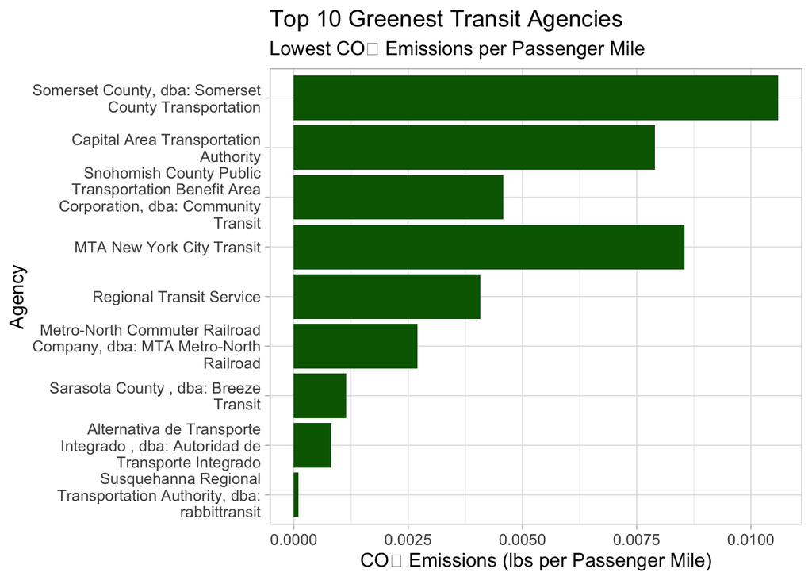

```r
library(dplyr)
library(ggplot2)
library(stringr)

top_greenest <- NTD_JOINED %>%
  filter(!is.na(Emissions_per_Passenger_Mile), Emissions_per_Passenger_Mile > 0) %>%
  arrange(Emissions_per_Passenger_Mile) %>%
  slice(1:10)

#Reducing long agency names to display the graph properly
top_greenest$Agency <- str_wrap(top_greenest$Agency, width = 30)

ggplot(top_greenest, aes(x = reorder(Agency, Emissions_per_Passenger_Mile),
                         y = Emissions_per_Passenger_Mile)) +
  geom_col(fill = "darkgreen") +
  coord_flip() +
  labs(
    title = "Top 10 Greenest Transit Agencies",
    subtitle = "Lowest CO₂ Emissions per Passenger Mile",
    x = "Agency",
    y = "CO₂ Emissions (lbs per Passenger Mile)"
  ) +
  theme_light(base_size = 12)
```

#### Least Efficient Transit Agency Visualization

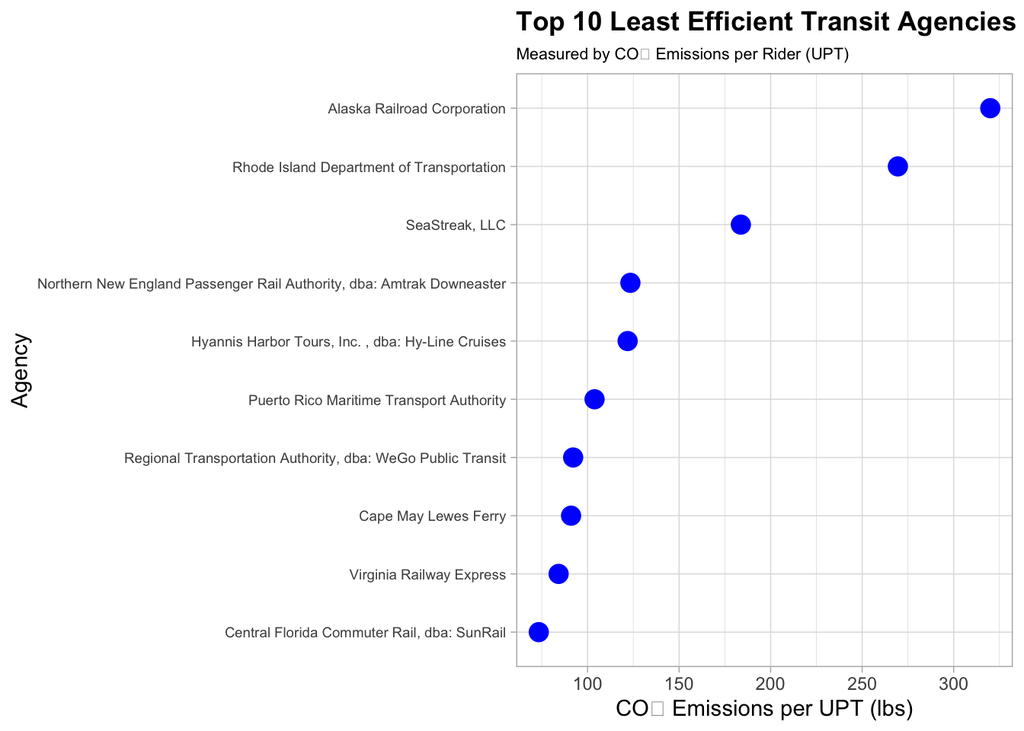

```r
library(dplyr)
library(ggplot2)

#Top 10 worst efficiency
worst_10 <- NTD_JOINED %>%
  filter(!is.na(Emissions_per_UPT), Emissions_per_UPT > 0) %>%
  arrange(desc(Emissions_per_UPT)) %>%
  slice(1:10)

#Dot plot with smaller y-axis text
ggplot(worst_10, aes(x = Emissions_per_UPT, y = reorder(Agency, Emissions_per_UPT))) +
  geom_point(color = "blue", size = 4) +
  labs(
    title = "Top 10 Least Efficient Transit Agencies",
    subtitle = "Measured by CO₂ Emissions per Rider (UPT)",
    x = "CO₂ Emissions per UPT (lbs)",
    y = "Agency"
  ) +
  theme_light(base_size = 11) +
  theme(
    axis.text.y = element_text(size = 7),
    #Shrinking y-axis label size
    plot.title = element_text(face = "bold"),
    plot.subtitle = element_text(size = 8)
  )
```

## Press Release

#### **Award Title :** Greenest Transit Agency

**Short description of the metric**  
To find the greenest agency, we looked at how much CO₂ is released for every mile a person travels. The lower the emissions per mile, the cleaner and more eco-friendly the service is.

**Name of the winning agency + value**  
The winner is Susquehanna Regional Transportation Authority, dba: rabbittransit, with only **0.000094 lbs CO₂ per passenger mile**.

**Reference value for context**

#### **Award Title :** Most Emissions Avoided

**Short description of the metric**  
To determine which agency made the biggest impact in reducing emissions, we calculated how much CO₂ would have been produced if all passengers had used personal vehicles instead. We then compared that to the agency’s actual transit emissions to find how much pollution was avoided.

**Name of the winning agency + value**  
The winner is **MTA New York City Transit**, which avoided approximately **8.54 billion lbs of CO₂** by providing efficient public transit instead of individual car trips.

**Reference value for context**  
This number stands out dramatically compared to other agencies, thanks to the MTA’s large ridership and high reliance on lower-emission rail systems.

#### **Award Title :** Most Multi-Modal Agency

**Short description of the metric**  
To determine the most multi-modal agency, we looked at how many different types of transit each agency runs—like buses, rail, or ferries. Agencies offering more modes typically provide more comprehensive service to a wider range of riders.

**Name of the winning agency + value**  
New Jersey Transit Corporation took the lead, operating six different transit modes. That variety reflects their strong commitment to providing flexible and accessible transportation options.

**Reference value for context**  
Since most agencies only run one or two modes, NJ Transit stands out as one of the most diverse and adaptable transit providers in the country.

#### **Award Title :** Least Efficient Transit Agency

**Short description of the metric**  
To determine which agency was the least efficient, we compared total CO₂ emissions to ridership numbers. Specifically, we calculated how many pounds of CO₂ were emitted for each individual passenger trip. The higher the number, the more inefficient the agency.

**Name of the winning agency + value**  
The Alaska Railroad Corporation stood out with an inefficiency score of **319.99**, meaning it emits nearly **320 pounds of CO₂** for every rider it serves.

**Reference value for context**

For context, the median transit agency emits **less than 3 pounds** of CO₂ per trip, making Alaska Railroad significantly less efficient than its peers.

#### Sources (APA Format)

- U.S. Energy Information Administration. (2023). *State Electricity Profiles*. U.S. Department of Energy. https://www.eia.gov/electricity/state/
- Federal Transit Administration. (2023). *2023 Annual Database: Energy Consumption*. U.S. Department of Transportation. https://www.transit.dot.gov/ntd/data-product/2023-annual-database-energy-consumption
- U.S. Department of Transportation. (2023). *2023 Service Data by Agency* [CSV file]. https://data.transportation.gov/resource/6y83-7vuw.csv